# Corine land cover analysis of Switzerland

RS-eco

2022-03-16

```r
library(dplyr); library(sf); library(ggplot2)
library(tidyr); library(scico)
```

```r
# Load shapefile of Europe & Switzerland
data("che", package="sdc")
che_laea <- sf::st_transform(che, "+proj=laea +lat_0=52 +lon_0=10 +x_0=4321000 +y_0=3210000 +ellps=GRS80 +towgs84=0,0,0,0,0,0,0 +units=m +no_defs")
```

# General information

The land cover data originates from: https://land.copernicus.eu/pan-european/corine-land-cover There you can also find additional information on the data.

The data is based on satellite images and there is data for 5 different years (1990, 2000, 2006, 2012, 2018). The data originally has a resolution of 100 x 100 m. In this resolution there is one land cover class per grid cell.

The European data was aggregated to a coarser resolution and contain for each land-cover class the percentage cover per grid cell.

Overall, the dataset discriminates between 45 different land-cover classes:

Continuous urban fabric, Discontinuous urban fabric, Industrial or commercial units, Road and rail networks and associated land, Port areas, Airports, Mineral extraction sites, Dump sites, Construction sites, Green urban areas, Sport and leisure facilities, Non-irrigated arable land, Permanently irrigated land, Rice fields, Vineyards, Fruit trees and berry plantations, Olive groves, Pastures, Annual crops associated with permanent crops, Complex cultivation patterns, Land principally occupied by agriculture with significant areas of natural vegetation, Agro-forestry areas, Broad-leaved forest, Coniferous forest, Mixed forest, Natural grasslands, Moors and heathland, Sclerophyllous vegetation, Transitional woodland-shrub, Beaches dunes sands, Bare rocks, Sparsely vegetated areas, Burnt areas, Glaciers and perpetual snow, Inland marshes, Peat bogs, Salt marshes, Salines, Intertidal flats, Water courses, Water bodies, Coastal lagoons, Estuaries, Sea and ocean, NODATA

## Colour key of Corine land-cover classes

Each land-cover class is associated with a certain colour, which are provided here:

```r
# Named vector of clc colours
clc_cols <- c("Continuous urban fabric" = "#e6004d", "Discontinuous urban fabric" = "#ff0000", "Industrial or commercial units" = "#cc4df2", "Road and rail networks and associated land" = "#cc0000", "Port areas" = "#e6cccc", "Airports" = "#e6cce6", "Mineral extraction sites" = "#a600cc", "Dump sites" = "#a64d00", "Construction sites" = "#ff4dff", "Green urban areas" = "#ffa6ff", "Sport and leisure facilities" = "#ffe6ff", "Non-irrigated arable land" = "#ffffa8", "Permanently irrigated land" = "#ffff00", "Rice fields" = "#e6e600", "Vineyards" = "#e68000", "Fruit trees and berry plantations" = "#f2a64d", "Olive groves" = "#e6a600", "Pastures" = "#e6e64d", "Annual crops associated with permanent crops" = "#ffe6a6", "Complex cultivation patterns" = "#ffe64d", "Land principally occupied by agriculture with \n significant areas of natural vegetation" = "#e6cc4d", "Agro-forestry areas" = "#f2cca6", "Broad-leaved forest" = "#80ff00", "Coniferous forest" = "#00a600", "Mixed forest" = "#4dff00", "Natural grasslands" = "#ccf24d", "Moors and heathland" = "#a6ff80", "Sclerophyllous vegetation" = "#a6e64d", "Transitional woodland-shrub" = "#a6f200", "Beaches - dunes - sands" = "#e6e6e6", "Bare rocks" = "#cccccc", "Sparsely vegetated areas" = "#ccffcc", "Burnt areas" = "#000000", "Glaciers and perpetual snow" = "#a6e6cc", "Inland marshes" = "#a6a6ff", "Peat bogs" = "#4d4dff", "Salt marshes" = "#ccccff", "Salines" = "#e6e6ff", "Intertidal flats" = "#a6a6e6", "Water courses" = "#00ccf2", "Water bodies" = "#80f2e6", "Coastal lagoons" = "#00ffa6", "Estuaries" = "#a6ffe6", "Sea and ocean" = "#e6f2ff", "NODATA" = "#ffffff")
```

# Data Analysis

Here, I perform a first analysis of the Corine Land-Cover and Land-Cover Change Data for Europe.

The Corine LC data for Switzerland (corine_lc_cha.rda), which I use here, can be downloaded from https://github.com/RS-eco/sdc/blob/main/data/.

The code for how the CLC data (corine_lc_che.rda) was created can be found here: https://github.com/RS-eco/edc/blob/main/data-raw/corine_lc_che.R.

## Corine land-cover of Switzerland

### Map of land cover of Switzerland for 2000

```r
data("corine_lc_che", package="sdc")
corine_lc_che <- corine_lc_che %>% group_by(x,y) %>%
  pivot_longer(cols=!c("x","y"), names_to = "year", values_to="clc"); gc()
```

```
#>             used   (Mb) gc trigger   (Mb)  max used   (Mb)
#> Ncells   7190415  384.1   17782024  949.7  11329973  605.1
#> Vcells 198156585 1511.9  374112371 2854.3 348998525 2662.7
```

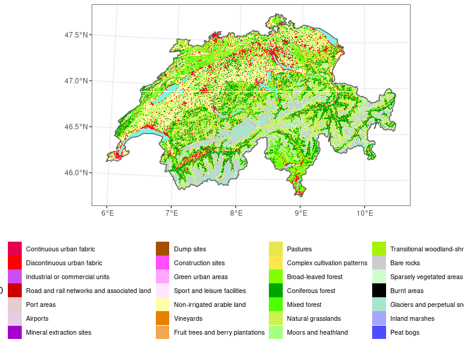

```r
corine_lc_che$present <- 1
corine_lc_che$year <- as.numeric(corine_lc_che$year)

clc_cols_che <- clc_cols[names(clc_cols) %in% corine_lc_che$clc]
corine_lc_che %>% filter(year == 2000) %>%
  ggplot() + geom_tile(aes(x=x, y=y, fill=clc)) +
  scale_fill_manual(name="CLC2000", values=clc_cols_che) +
  geom_sf(data=che_laea, fill=NA) + coord_sf() + theme_bw() +
  theme(legend.position="bottom", legend.text = element_text(size=8)) +
  labs(x="", y=""); invisible(gc())
```

### Forest map for 2000

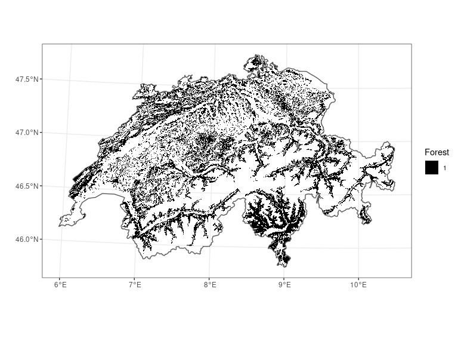

```r
lc_che <- corine_lc_che %>% filter(year == 2000) %>%
  filter(clc %in% c("Coniferous forest", "Mixed forest", "Broad-leaved forest")) %>%
  pivot_wider(names_from="clc", values_from="present", values_fill = 0) %>%
  mutate(forest = `Coniferous forest` + `Mixed forest` + `Broad-leaved forest`); invisible(gc())

# Plot forest map
lc_che %>% ggplot() + geom_tile(aes(x=x, y=y, fill=as.factor(forest))) +
  geom_sf(data=che_laea, fill=NA) + coord_sf() +
  scale_fill_manual(name="Forest", values=c("black")) +
  theme_bw() + labs(x="", y="") +
  theme(legend.text = element_text(size=8))
```

```r
rm(lc_che); invisible(gc())
```

### Map of selected single land-cover classes against year

```r
corine_lc_che <- corine_lc_che %>% filter(year != 1990) %>%
  filter(clc %in% c("Pastures", "Broad-leaved forest", "Coniferous forest", "Mixed forest", "Natural grasslands")); gc()
```

```
#>             used   (Mb) gc trigger   (Mb)  max used   (Mb)
#> Ncells   6676407  356.6   20557239 1097.9  32120684 1715.5
#> Vcells 151975256 1159.5  518496122 3955.9 539512627 4116.2
```

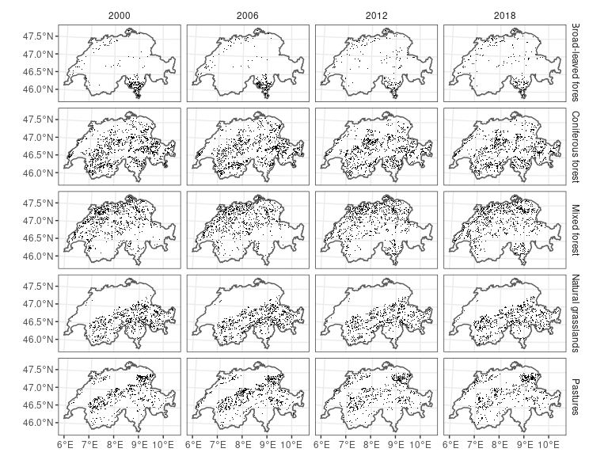

```r
corine_lc_che %>% ggplot() + geom_tile(aes(x=x, y=y), fill="black") +
  facet_grid(clc~year) + geom_sf(data=che_laea, fill=NA) + coord_sf() +
  theme_bw() + labs(x="", y="") +
  theme(strip.background = element_blank(), axis.title = element_blank())
```

### Aggregating land-cover data of Switzerland

```r
library(raster)
vars <- unique(corine_lc_che$clc)
years <- c(1990,2000,2006,2012,2018)
clc_dat <- lapply(vars, function(z){
  dat <- corine_lc_che %>% filter(clc == z) %>%
    dplyr::select(-clc) %>% group_by(x,y) %>%
    tidyr::pivot_wider(names_from="year", values_from="present") %>%
    raster::rasterFromXYZ() %>%
    raster::aggregate(fact=50, fun=sum, expand=T, na.rm=T)
  dat <- dat/25
  return(dat)
}); rm(corine_lc_che); gc()
```

```
#>             used   (Mb) gc trigger   (Mb)  max used   (Mb)
#> Ncells   5557481  296.9   16445792  878.4  32120684 1715.5
#> Vcells 141932745 1082.9  416158076 3175.1 539512627 4116.2
```

```r
clc_dat[[1]]
```

```
#> class      : RasterBrick
#> dimensions : 44, 70, 3080, 4  (nrow, ncol, ncell, nlayers)
#> resolution : 5000, 5000  (x, y)
#> extent     : 4011200, 4361200, 2524900, 2744900  (xmin, xmax, ymin, ymax)
#> crs        : NA
#> source     : memory
#> names      : X2000, X2006, X2012, X2018
#> min values :  0.04,  0.04,  0.04,  0.04
#> max values : 74.52, 73.84, 73.44, 73.44
```

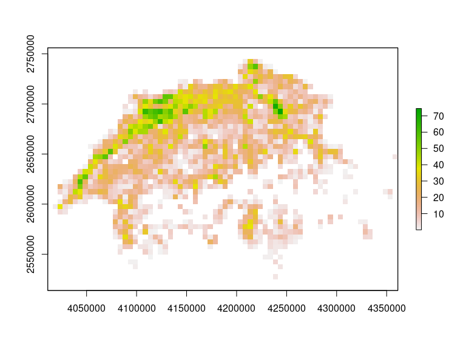

```r
raster::plot(clc_dat[[1]][[1]])
```

```r
# Define CRS (WGS84)
clc_dat <- lapply(clc_dat, function(x){
  raster::crs(x) <- "+proj=laea +lat_0=52 +lon_0=10 +x_0=4321000 +y_0=3210000 +ellps=GRS80
+towgs84=0,0,0,0,0,0,0 +units=m +no_defs"
  return(x)
})

# Turn into data.frame
clc_dat <- lapply(1:length(clc_dat), function(x){
  tryCatch({
    dat <- raster::rasterToPoints(clc_dat[[x]]) %>% as.data.frame()
    colnames(dat)
    dat$var <- vars[x]
    return(dat)
  }, error = function(e){
    return(NULL)
  })
}); invisible(gc())
clc_dat <- Filter(Negate(is.null), clc_dat)
clc_dat <- data.table::rbindlist(clc_dat, fill=T)
head(clc_dat)
```

```
#>          x       y X2000 X2006 X2012 X2018          var
#> 1: 4208700 2742400  1.28  5.36  3.36  3.28 Mixed forest
#> 2: 4213700 2742400 32.40 32.00 39.40 39.40 Mixed forest
#> 3: 4218700 2742400 11.48 11.64 14.68 14.68 Mixed forest
#> 4: 4223700 2742400  0.56  0.64  1.32  1.40 Mixed forest
#> 5: 4203700 2737400  1.88  2.52  9.56  9.56 Mixed forest
#> 6: 4208700 2737400 11.60 12.52 14.76 14.76 Mixed forest
```

```r
# Re-structure data.frame & define categories
clc_dat <- clc_dat %>% group_by(x,y,var) %>%
  tidyr::pivot_longer(names_to="year", values_to="perc_cover", -group_cols()) %>%
  tidyr::drop_na() %>% mutate(year = as.numeric(sub("X", "", year))) %>%
  mutate(var = factor(var, levels = c("Continuous urban fabric", "Discontinuous urban fabric", "Industrial or commercial units", "Road and rail networks and associated land", "Port areas", "Airports", "Mineral extraction sites", "Dump sites", "Construction sites", "Green urban areas", "Sport and leisure facilities", "Non-irrigated arable land", "Permanently irrigated land", "Rice fields", "Vineyards", "Fruit trees and berry plantations", "Olive groves", "Pastures", "Annual crops associated with permanent crops", "Complex cultivation patterns", "Land principally occupied by agriculture with significant areas of natural vegetation", "Agro-forestry areas", "Broad-leaved forest", "Coniferous forest", "Mixed forest", "Natural grasslands", "Moors and heathland", "Sclerophyllous vegetation", "Transitional woodland-shrub", "Beaches dunes sands", "Bare rocks", "Sparsely vegetated areas", "Burnt areas", "Glaciers and perpetual snow", "Inland marshes", "Peat bogs", "Salt marshes", "Salines", "Intertidal flats", "Water courses", "Water bodies", "Coastal lagoons", "Estuaries", "Sea and ocean", "NODATA", "NA"))) %>%
  tidyr::pivot_wider(names_from="year", values_from="perc_cover", values_fill = 0)
corine_lc_che_10km <- clc_dat[rowSums(clc_dat[,-c(1,2,3)], na.rm=T) != 0,]; rm(clc_dat); gc()
```

```
#>             used   (Mb) gc trigger   (Mb)  max used   (Mb)
#> Ncells   5626277  300.5   16445792  878.4  32120684 1715.5
#> Vcells 142089762 1084.1  416158076 3175.1 539512627 4116.2
```

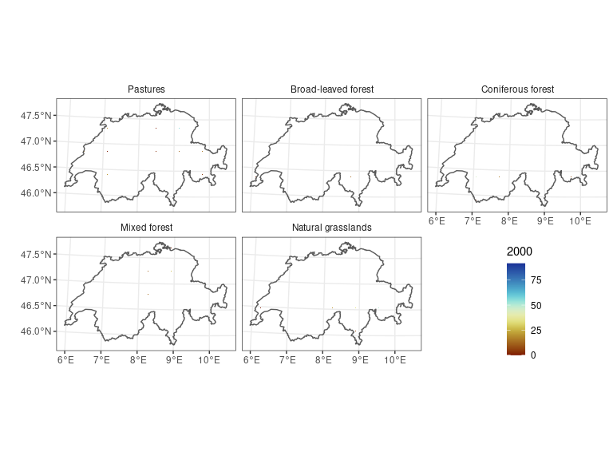

```r
# Plot aggregated data
library(ggplot2)
corine_lc_che_10km %>%
  filter(var %in% c("Olive groves", "Pastures", "Complex cultivation patterns",
                    "Agro-forestry areas", "Broad-leaved forest", "Coniferous forest",
                    "Mixed forest", "Natural grasslands", "Beaches dunes sands")) %>%
  ggplot() + geom_tile(aes(x=x, y=y, fill=`2000`)) +
  geom_sf(data=che_laea, fill=NA) + facet_wrap(var ~ .) +
  scale_fill_scico(palette="roma") + coord_sf() + theme_bw() + labs(x="", y="") +
  theme(legend.position=c(0.85,0.2), strip.background=element_blank())
```

### Land-cover change

```r
data("corine_cha_che", package="sdc")
corine_cha_che <- corine_cha_che %>%
  unite("9000", c("9000_90", "9000_00"), sep=" - ", na.rm=T) %>%
  unite("0006", c("0006_00", "0006_06"), sep=" - ", na.rm=T) %>%
  unite("0612", c("0612_06", "0612_12"), sep=" - ", na.rm=T) %>%
  unite("1218", c("1218_12", "1218_18"), sep=" - ", na.rm=T)
head(corine_cha_che)
```

```
#>             x       y    9000    0006    0612
#> 23947 4225350 2731050 NA - NA NA - NA NA - NA
#> 23948 4225450 2731050 NA - NA NA - NA NA - NA
#> 23949 4225550 2731050 NA - NA NA - NA NA - NA
#> 24251 4225250 2730950 NA - NA NA - NA NA - NA
#> 24252 4225350 2730950 NA - NA NA - NA NA - NA
#> 24253 4225450 2730950 NA - NA NA - NA NA - NA
#>                                                      1218
#> 23947 Construction sites - Industrial or commercial units
#> 23948 Construction sites - Industrial or commercial units
#> 23949 Construction sites - Industrial or commercial units
#> 24251 Construction sites - Industrial or commercial units
#> 24252 Construction sites - Industrial or commercial units
#> 24253 Construction sites - Industrial or commercial units
```

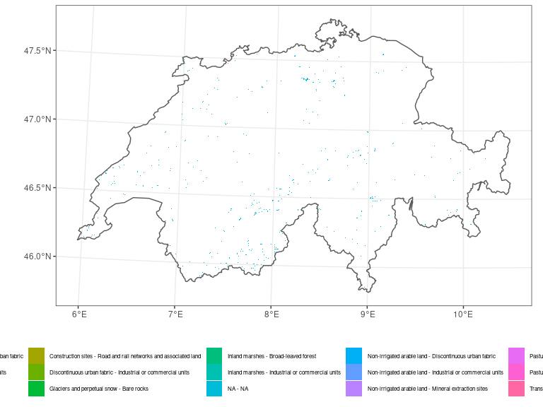

```r
#clc_cols_1990 <- clc_cols[names(clc_cols) %in% corine_lc_bav_tk4tel$`1990`]
corine_cha_che %>% ggplot() + geom_tile(aes (x=x, y=y, fill=`9000`)) +
  #scale_fill_manual(name="CLC 1990", values=clc_cols_1990) +
  geom_sf(data=che_laea, fill=NA) + coord_sf() + theme_bw() + labs(x="", y="") +
  theme(legend.position="bottom", legend.text = element_text(size=6))
```

```r
rm(list=ls()); invisible(gc())
```